# **ggplot2: Elegante Datenvisualisierung**

Index: https://fallenengels.github.io/R-basics

## Inhalt

Warum ggplot2?  
Modularität: Sei meine Leinwand  
Alle Informationen auf einmal  
Präsentation und Farben  
Spezialisierte Anwendungen und Tricks

## Warum ggplot2?

Obwohl bereits base-R die Möglichkeit bietet, schnell informative Grafiken zu erstellen, sind diese einerseits meistens nicht wirklich schön anzusehen (Stichwort Präsentation von Daten in Forschungsarbeiten), und andererseits durch den Ersteller nicht gut zu bearbeiten. Das Paket `ggplot2` macht es sich zur Aufgabe, diese beiden Probleme zu lösen, damit sich schöne und übersichtliche Grafiken erzeugen lassen können:

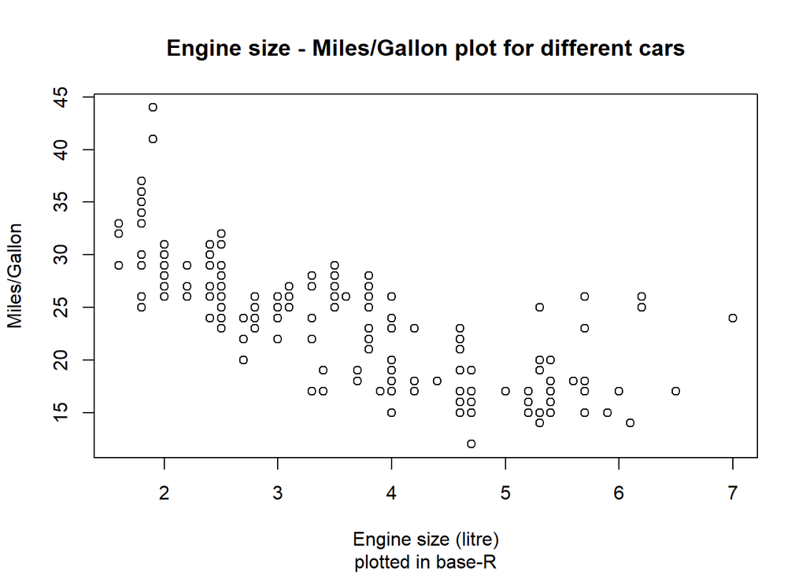

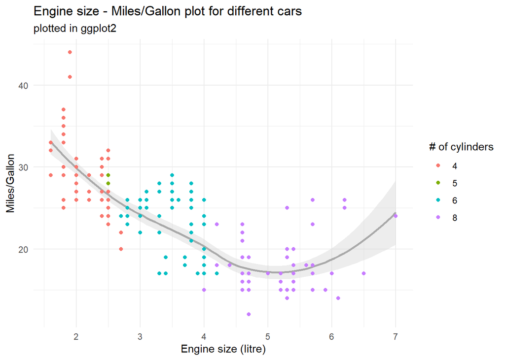

```r
data(mpg)

# plotting mit base-R command plot()
plot(mpg$displ, mpg$hwy, main = "Engine size - Miles/Gallon plot for different cars",
     sub = "plotted in base-R", xlab = "Engine size (litre)", ylab = "Miles/Gallon")

# plotting mit ggplot2 command ggplot()
mpg %>% mutate(cyl = as.factor(cyl)) %>%
  ggplot(aes(x = displ, y = hwy)) +
  geom_smooth(colour = "dark gray", fill = "light gray") + geom_point(aes(colour = cyl)) + theme_minimal() +
  labs(title = "Engine size - Miles/Gallon plot for different cars",
       subtitle = "plotted in ggplot2",
       x = "Engine size (litre)", y = "Miles/Gallon", colour = "# of cylinders")
```

Zwei Dinge sollten hierbei klar ersichtlich sein: Zum einen eignet sich ggplot2 für eine deutlich schönere Präsentation, in der zudem über z.B. Farben noch weitere Informationen kommuniziert werden können. Zum anderen ist ggplot was den Aufbau einer Grafik angeht jedoch um einiges komplexer als die base-R `plot()`-Funktion.

Diese Komplexität resultiert daraus, dass ggplot2 auf einer zugrundeliegenden, standardisierten [**Grammar of Graphics** basiert](http://vita.had.co.nz/papers/layered-grammar.pdf) (daher das gg). Glücklicherweise ist dabei vieles der wahrgenommenen Komplexität auf die dieser Grammatik zugrundeliegenden Modularität in der Grafikgenerierung geschuldet. Sobald diese Modularität einmal verstanden ist (was ich im Folgenden mit einer kurzen Erklärung und Demonstration versuchen werde), sollte einiges der Komplexität aus der Grafikerstellung verschwinden, und vieles Sinn ergeben.